# Course Project Description

March.12, 2022

## Abstract

This data set is a record of Covid-19 report from WHO(https://covid19.who.int/WHO-COVID-19-global-data.csv) across the world. It contains the number of daily new cases from every country, as well as cumulative cases, new deaths and cumulative deaths dated from 2020-1-3 to 2022-3-11.

In this project, the aim is to test whether there are any differences in the mean overall case-fatality rate across WHO Regions from March 2020 to February 2021 in 4 different seasons.The seasons are separated as the following:

Spring: March-May; Summer: June-August; Fall: September-November; Winter: December-February  
The null hypothesis H0: the mean case-fatality in each season across different WHO Regions are the same

The alternative hypothesis Ha:the mean case-fatality in each season across different WHO Regions are not the same  
Alpha is at default 0.05

# Background

Coronavirus pandemic is a pandemic caused by the spread of severe acute respiratory disease SARS-CoV-2. It was first identified amid an outbreak of unknown respiratory illness cases in Wuhan, China.

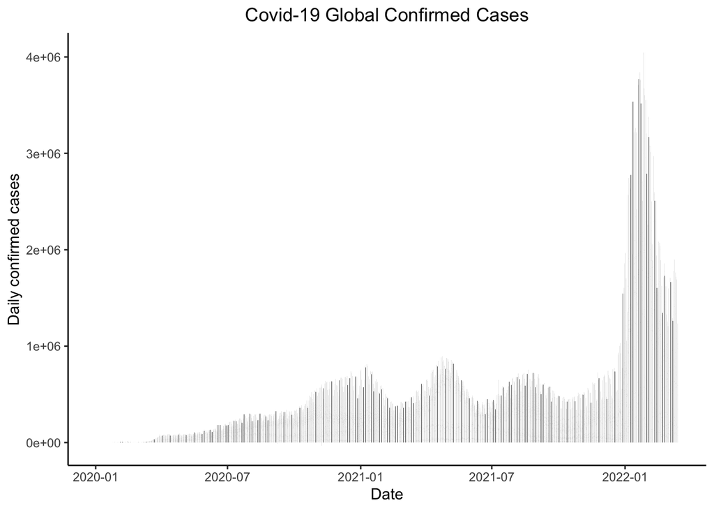

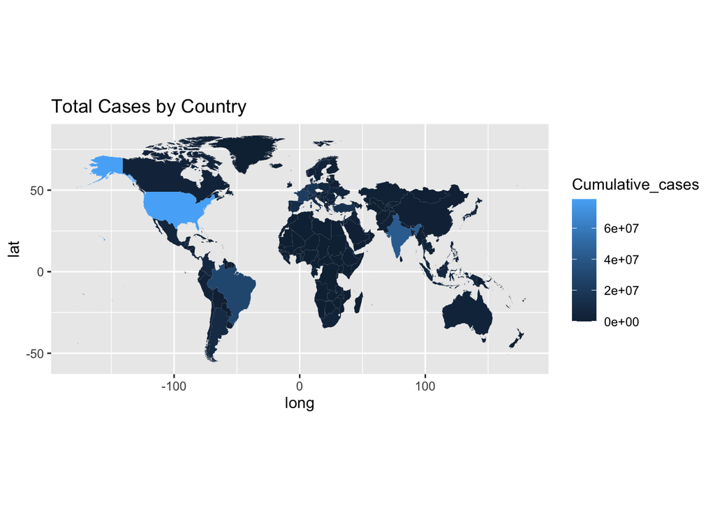

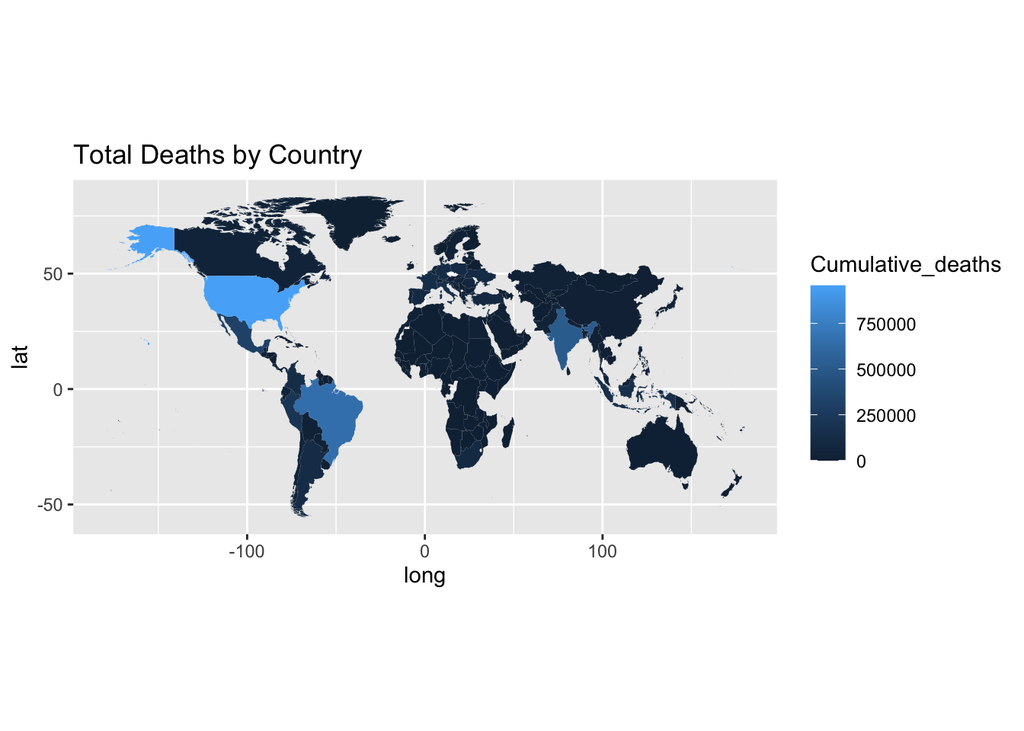

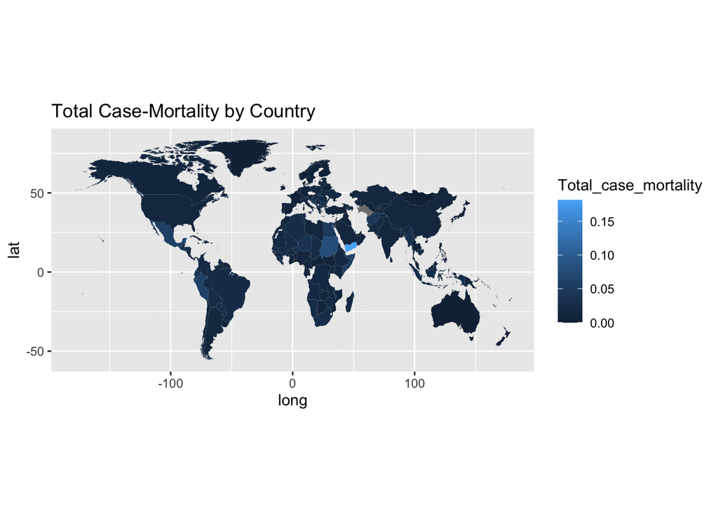

## Descriptive Analysis

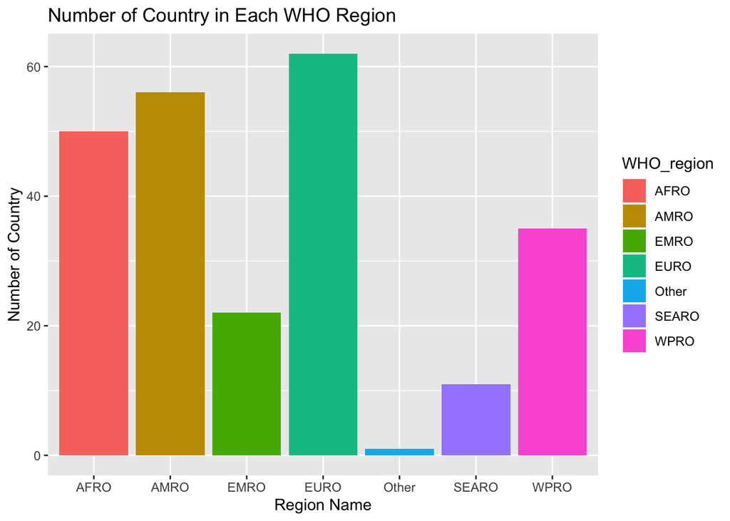

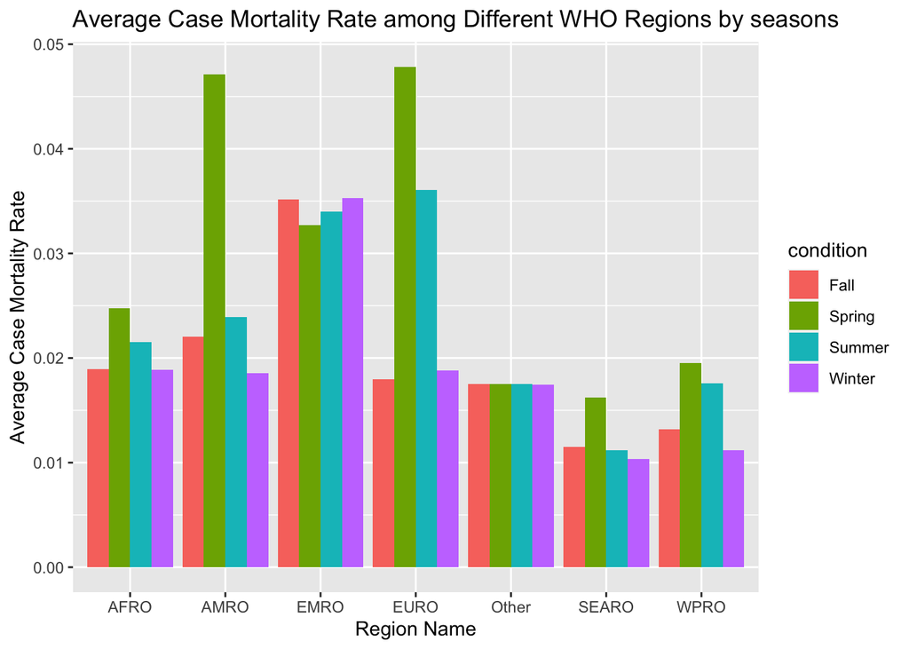

```
## # A tibble: 7 x 5
##   WHO_region Spring Summer   Fall Winter
##   <chr>       <dbl>  <dbl>  <dbl>  <dbl>
## 1 AFRO       0.0248 0.0215 0.0189 0.0189
## 2 AMRO       0.0471 0.0239 0.0220 0.0185
## 3 EMRO       0.0327 0.0340 0.0352 0.0353
## 4 EURO       0.0477 0.0360 0.0180 0.0188
## 5 Other      0.0175 0.0175 0.0175 0.0174
## 6 SEARO      0.0163 0.0112 0.0115 0.0103
## 7 WPRO       0.0195 0.0176 0.0132 0.0112
```

```
##    regions.list condition Mortality.list index
## 1          AFRO    Spring     0.02477735     1
## 2          AFRO    Summer     0.02153480     2
## 3          AFRO      Fall     0.01891260     3
## 4          AFRO    Winter     0.01885059     4
## 5          AMRO    Spring     0.04712312     1
## 6          AMRO    Summer     0.02392653     2
## 7          AMRO      Fall     0.02204808     3
## 8          AMRO    Winter     0.01853969     4
## 9          EMRO    Spring     0.03273641     1
## 10         EMRO    Summer     0.03397348     2
## 11         EMRO      Fall     0.03519294     3
## 12         EMRO    Winter     0.03529196     4
## 13         EURO    Spring     0.04783930     1
## 14         EURO    Summer     0.03605282     2
## 15         EURO      Fall     0.01798525     3
## 16         EURO    Winter     0.01883095     4
## 17        Other    Spring     0.01754386     1
## 18        Other    Summer     0.01754386     2
## 19        Other      Fall     0.01754386     3
## 20        Other    Winter     0.01744966     4
## 21        SEARO    Spring     0.01625557     1
## 22        SEARO    Summer     0.01116495     2
## 23        SEARO      Fall     0.01149846     3
## 24        SEARO    Winter     0.01032999     4
## 25         WPRO    Spring     0.01949783     1
## 26         WPRO    Summer     0.01759734     2
## 27         WPRO      Fall     0.01320489     3
## 28         WPRO    Winter     0.01115031     4
```

## Inferential Analysis

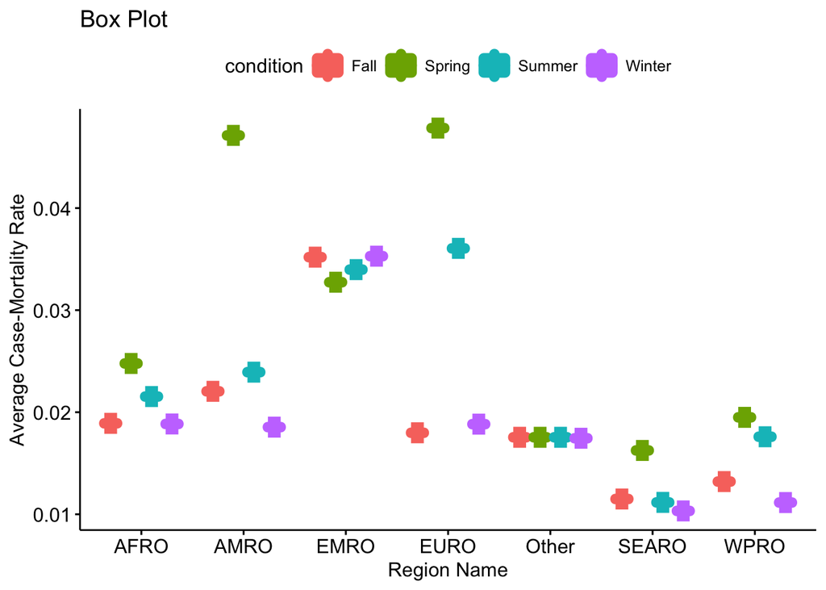

## Sensitivity Analysis

From the plot “the Residual vs Fitted plot” we can tell there is no evident relationship between residuals and fitted values. This indicates that we can assume the homogeneity of variances, which is an assumption of two-way anova test.

The tukey output includes all comparisons across all WHO regions, the mean differences for each comparison, as well as the lower-bound, upper-bond, and the adjusted p-value.

```
## Call:
##    aov(formula = Mortality.list ~ regions.list * index, data = season.df.)
##
## Terms:
##                 regions.list        index regions.list:index    Residuals
## Sum of Squares  0.0016358381 0.0004514374       0.0005680248 0.0002053888
## Deg. of Freedom            6            1                  6           14
##
## Residual standard error: 0.003830226
## Estimated effects may be unbalanced
```

```
##                    Df    Sum Sq   Mean Sq F value   Pr(>F)
## regions.list        6 0.0016358 0.0002726  18.584 6.30e-06 ***
## index               1 0.0004514 0.0004514  30.772 7.19e-05 ***
## regions.list:index  6 0.0005680 0.0000947   6.453  0.00198 **
## Residuals          14 0.0002054 0.0000147
## ---
## Signif. codes:  0 '***' 0.001 '**' 0.01 '*' 0.05 '.' 0.1 ' ' 1
```

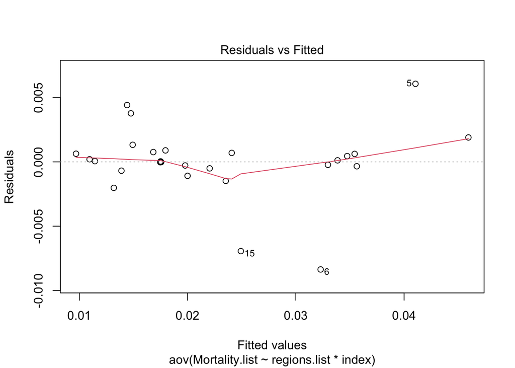

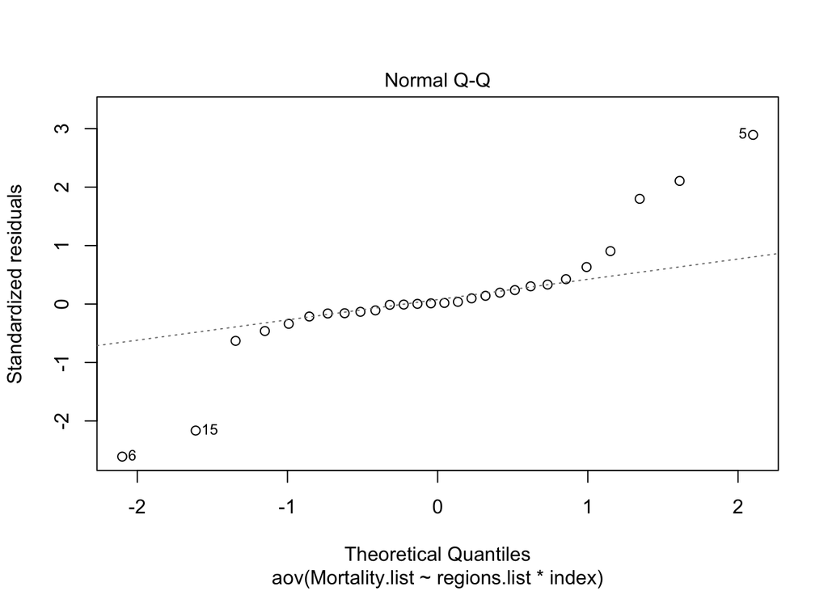

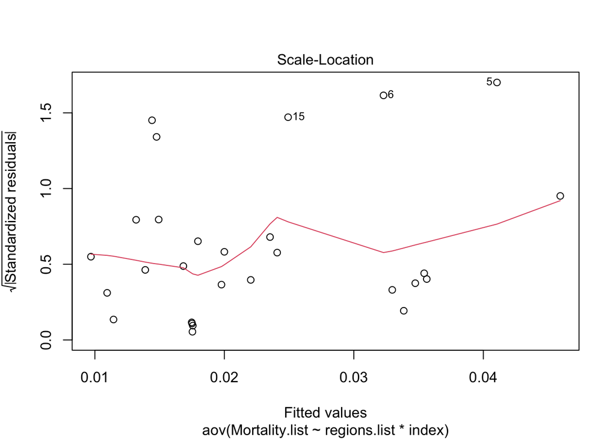

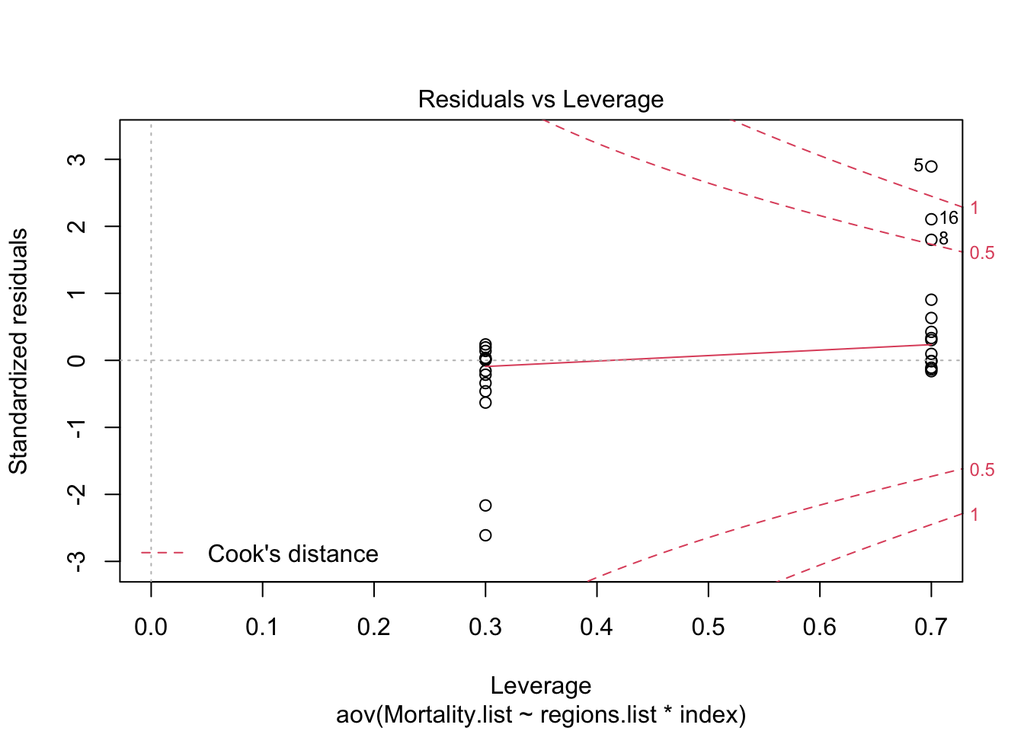

```
##   Tukey multiple comparisons of means
##     95% family-wise confidence level
##
## Fit: aov(formula = Mortality.list ~ regions.list * index, data = season.df.)
##
## $regions.list
##                     diff           lwr          upr     p adj
## AMRO-AFRO    0.006890520 -2.357473e-03  0.016138513 0.2155509
## EMRO-AFRO    0.013279862  4.031869e-03  0.022527856 0.0033771
## EURO-AFRO    0.009158245 -8.974846e-05  0.018406238 0.0530338
## Other-AFRO  -0.003498525 -1.274652e-02  0.005749468 0.8448920
## SEARO-AFRO  -0.008706593 -1.795459e-02  0.000541401 0.0711425
## WPRO-AFRO   -0.005656243 -1.490424e-02  0.003591751 0.4085408
## EMRO-AMRO    0.006389342 -2.858651e-03  0.015637336 0.2835915
## EURO-AMRO    0.002267725 -6.980268e-03  0.011515718 0.9763584
## Other-AMRO  -0.010389045 -1.963704e-02 -0.001141052 0.0234015
## SEARO-AMRO  -0.015597113 -2.484511e-02 -0.006349119 0.0007568
## WPRO-AMRO   -0.012546763 -2.179476e-02 -0.003298769 0.0054940
## EURO-EMRO   -0.004121617 -1.336961e-02  0.005126376 0.7287811
## Other-EMRO  -0.016778387 -2.602638e-02 -0.007530394 0.0003640
## SEARO-EMRO  -0.021986455 -3.123445e-02 -0.012738462 0.0000190
## WPRO-EMRO   -0.018936105 -2.818410e-02 -0.009688112 0.0001014
## Other-EURO  -0.012656770 -2.190476e-02 -0.003408777 0.0051055
## SEARO-EURO  -0.017864838 -2.711283e-02 -0.008616844 0.0001894
## WPRO-EURO   -0.014814488 -2.406248e-02 -0.005566494 0.0012438
## SEARO-Other -0.005208068 -1.445606e-02  0.004039926 0.4978385
## WPRO-Other  -0.002157718 -1.140571e-02  0.007090276 0.9814870
## WPRO-SEARO   0.003050350 -6.197643e-03  0.012298343 0.9094602
```

## Conclusion

From the summary of two-way ANOVA, we can see that the p-value for both WHO regions and season are significant. This suggests that the null hypothesis is rejected in favor of the alternative hypothesis and alpha = 0.05. In conclusion,the mean case-fatality in each season across different WHO Regions are not the same.

However, if we want to take a closer look at each comparison, from the Tukey table above we can make conclusion about whether all comparisons share the same mean, the following comparison have a smaller p-value than alpha, therefore they reject the null hypothesis:  
EMRO-AFRO  
Other-AMRO  
SEARO-AMRO  
WPRO-AMRO  
Other-EMRO  
SEARO-EMRO  
WPRO-EMRO  
Other-EURO  
SEARO-EURO  
WPRO-EURO  
Meanwhile, the rest of the comparisons fail to reject the null hypothesis.

## Appendix R Code and Output

```r
library(tidyverse)
covid <- read_csv("https://covid19.who.int/WHO-COVID-19-global-data.csv")
```

```r
summary(covid)
length(unique(covid$Country))
length(unique(covid$WHO_region))
length(unique(covid$Country_code))
case.mortality<-lm(covid$Cumulative_deaths~covid$Cumulative_cases)
summary(case.mortality)

ggplot(covid, aes(x=Date_reported, y=New_cases)) + geom_bar(stat="identity", width=0.1) +
  theme_classic() +
  labs(title = "Covid-19 Global Confirmed Cases", x= "Date", y= "Daily confirmed cases") +
  theme(plot.title = element_text(hjust = 0.5))
```

```r
library(maps)

world <- map_data("world");

covid.total<- covid %>% filter(Date_reported == '2022-3-11')
covid.total$Country[227] <- 'USA'
covid.total$Country[228] <- 'USA'
covid.total$Country[25] <- 'Bolivia'

covid.total<- covid.total %>% mutate(region=Country)
covid.total<- inner_join(world, covid.total, by = "region")

covid.map.total.cases<- ggplot() +
  geom_polygon(data = covid.total, aes(x=long, y = lat, group = group,
    fill= Cumulative_cases)) + coord_fixed(1.3) + ggtitle('Total Cases by Country')
covid.map.total.cases
```

```r
covid.map.total.deaths<-ggplot() +
  geom_polygon(data = covid.total, aes(x=long, y = lat, group = group,
    fill= Cumulative_deaths)) + coord_fixed(1.3) + ggtitle('Total Deaths by Country')
covid.map.total.deaths
```

```r
covid.total<- covid.total%>% mutate(Total_case_mortality = Cumulative_deaths/Cumulative_cases)

covid.map.total.case.mortality<-ggplot() +
  geom_polygon(data = covid.total, aes(x=long, y = lat, group = group,
    fill= Total_case_mortality)) + coord_fixed(1.3) + ggtitle('Total Case-Mortality by Country')
covid.map.total.case.mortality
```

```r
spring<- covid %>% filter(across(Date_reported, ~ grepl('2020-03|2020-04|2020-05',.)))%>% mutate(Case_mortality = Cumulative_deaths/Cumulative_cases)%>% filter(Date_reported == '2020-05-31')%>%select(WHO_region,Case_mortality)
summer<- covid %>% filter(across(Date_reported, ~ grepl('2020-06|2020-07|2020-08',.)))%>% mutate(Case_mortality = Cumulative_deaths/Cumulative_cases)%>% filter(Date_reported == '2020-08-31')%>%select(Case_mortality)
fall<- covid %>% filter(across(Date_reported, ~ grepl('2020-09|2020-10|2020-11',.)))%>% mutate(Case_mortality = Cumulative_deaths/Cumulative_cases)%>% filter(Date_reported == '2020-11-30')%>%select(Case_mortality)
winter<- covid %>% filter(across(Date_reported, ~ grepl('2020-12|2021-01|2021-02',.)))%>% mutate(Case_mortality = Cumulative_deaths/Cumulative_cases)%>% filter(Date_reported == '2021-02-28')%>%select(Case_mortality)

season<-bind_cols(c(spring,summer,fall,winter))
```

```
## * Case_mortality -> Case_mortality...2
## * Case_mortality -> Case_mortality...3
## * Case_mortality -> Case_mortality...4
## * Case_mortality -> Case_mortality...5
```

```r
colnames(season)<-c('WHO_region','Spring','Summer','Fall','Winter')

AFRO<- season%>%filter(WHO_region == 'AFRO') %>% mutate(Spring = mean(na.omit(Spring)))  %>% mutate(Summer = mean(na.omit(Summer))) %>% mutate(Fall = mean(na.omit(Fall))) %>% mutate(Winter = mean(na.omit(Winter))) %>% head(1)
AMRO<- season%>%filter(WHO_region == 'AMRO') %>% mutate(Spring = mean(na.omit(Spring)))  %>% mutate(Summer = mean(na.omit(Summer))) %>% mutate(Fall = mean(na.omit(Fall))) %>% mutate(Winter = mean(na.omit(Winter))) %>% head(1)
EMRO<- season%>%filter(WHO_region == 'EMRO') %>% mutate(Spring = mean(na.omit(Spring)))  %>% mutate(Summer = mean(na.omit(Summer))) %>% mutate(Fall = mean(na.omit(Fall))) %>% mutate(Winter = mean(na.omit(Winter))) %>% head(1)
EURO<- season%>%filter(WHO_region == 'EURO') %>% mutate(Spring = mean(na.omit(Spring)))  %>% mutate(Summer = mean(na.omit(Summer))) %>% mutate(Fall = mean(na.omit(Fall))) %>% mutate(Winter = mean(na.omit(Winter))) %>% head(1)
Other<- season%>%filter(WHO_region == 'Other') %>% mutate(Spring = mean(na.omit(Spring)))  %>% mutate(Summer = mean(na.omit(Summer))) %>% mutate(Fall = mean(na.omit(Fall))) %>% mutate(Winter = mean(na.omit(Winter))) %>% head(1)
SEARO<- season%>%filter(WHO_region == 'SEARO') %>% mutate(Spring = mean(na.omit(Spring)))  %>% mutate(Summer = mean(na.omit(Summer))) %>% mutate(Fall = mean(na.omit(Fall))) %>% mutate(Winter = mean(na.omit(Winter))) %>% head(1)
WPRO<- season%>%filter(WHO_region == 'WPRO') %>% mutate(Spring = mean(na.omit(Spring)))  %>% mutate(Summer = mean(na.omit(Summer))) %>% mutate(Fall = mean(na.omit(Fall))) %>% mutate(Winter = mean(na.omit(Winter))) %>% head(1)

season.df<-rbind(AFRO,AMRO,EMRO,EURO,Other,SEARO,WPRO)


plot.regions<-ggplot()+geom_bar(data=season,aes(x=WHO_region,fill=WHO_region))+xlab('Region Name')+ylab('Number of Country')+ggtitle('Number of Country in Each WHO Region')
plot.regions
```

```r
regions.list<- c(rep("AFRO",4),rep("AMRO",4),rep("EMRO",4),rep("EURO",4),rep("Other",4),rep("SEARO",4),rep("WPRO",4))

Mortality.list<-c(0.02477735,0.02153480,0.01891260,0.01885059,0.04712312,0.02392653,0.02204808,0.01853969,0.03273641,0.03397348,0.03519294,0.03529196,0.04783930,0.03605282,0.01798525,0.01883095,0.01754386,0.01754386,0.01754386,0.01744966,0.01625557,0.01116495,0.01149846,0.01032999,0.01949783,0.01759734,0.01320489,0.01115031)

condition<- c('Spring','Summer','Fall','Winter')
condition<- rep(condition,7)
index<-c(1,2,3,4,1,2,3,4,1,2,3,4,1,2,3,4,1,2,3,4,1,2,3,4,1,2,3,4)
season.df.<-data.frame(regions.list,condition,Mortality.list,index)

plot.seasons<-ggplot()+geom_bar(data=season.df.,aes(x=regions.list,y=Mortality.list,fill=condition),position = 'dodge', stat = 'identity')+xlab('Region Name')+ylab('Average Case Mortality Rate')+ggtitle('Average Case Mortality Rate among Different WHO Regions by seasons')
```

```r
library("ggpubr")

ggboxplot(season.df., x = "regions.list", y = "Mortality.list", color = "condition",size = 3,width=0.5,xlab='Region Name',ylab='Average Case-Mortality Rate',title='Box Plot')
```

```r
season.aov2 <- aov(Mortality.list ~ regions.list*index, data = season.df.)
summary(season.aov2)
season.aov2$residuals

TukeyHSD(season.aov2,which = 'regions.list')
plot(season.aov2)
```